# Toddler-friendly TripAdvisor Recommendations

This project is inspired by lack of toddler-friendly travel attractions. Most recommendation engines use a broad age range when defining "kid-friendly" although what is appropriate for a 10-year-old may not be suitable or safe for a 3-year-old.

The preliminary analysis looks at two of the attractions in Maui, HI to see if there is indeed a gap between what is recommended and what is appropriate for a toddler (preliminary analysis of need).

The second attraction is Baby Beach, which does not appear as one of the more popular destinations in Maui.

```python
import requests
from bs4 import BeautifulSoup
from wordcloud import WordCloud
import matplotlib.pyplot as plt
%matplotlib inline
```

```python
# get partial reviews for Haleakala National Park
reviews = []
for n in range(0, 40, 10):
    if n == 0:
        r = requests.get('https://www.tripadvisor.com/Attraction_Review-g60633-d2077822-Reviews-Haleakala_National_Park-Kula_Maui_Hawaii.html')
    else:
        r = requests.get('https://www.tripadvisor.com/Attraction_Review-g60633-d2077822-Reviews-or{}-Haleakala_National_Park-Kula_Maui_Hawaii.html'.format(n))
    soup = BeautifulSoup(r.content, 'html.parser')
    reviews.extend(soup.find_all('p', class_='partial_entry'))
```

```python
def make_wordcloud(reviews):
    '''
    makes wordcloud based in review texts
    input: list of reviews from beautifulsoup parsing
    '''
    reviews = list(map(lambda x: x.contents[0], reviews))
    text = ' '.join(reviews)
    wordcloud = WordCloud(max_font_size=40).generate(text)
    plt.figure(figsize=(15, 8))
    plt.imshow(wordcloud, interpolation='bilinear')
    plt.axis('off');
```

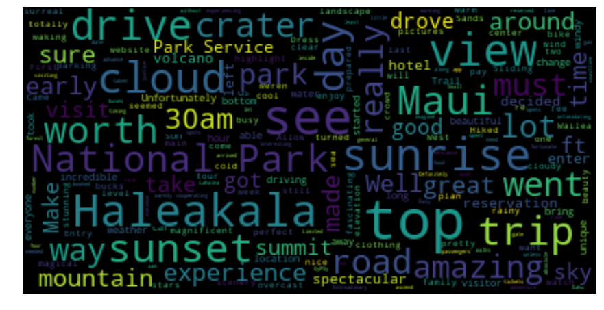

```python
make_wordcloud(reviews)
```

There are definite red flags for Haleakala National park.

- Someone with toddler would have a hard time making it to sunrise or sunset given toddler's sleep time.
- There are four different mention of car ride (drive, drove, driving, road), which may be difficult for small children.
- Mention of weather (cold, weather, overcast, wind) does not bode well for children's comorts.

All in all, Haleakala National Park does not seem like a great destination for families with toddlers, which I confirmed by reading through reviews in more depth.

```python
reviews2 = []
for n in range(0, 120, 10):
    if n == 0:
        r = requests.get('https://www.tripadvisor.com/Attraction_Review-g60634-d8661074-Reviews-Baby_Beach-Lahaina_Maui_Hawaii.html')
    else:
        r = requests.get('https://www.tripadvisor.com/Attraction_Review-g60634-d8661074-Reviews-or{}-Baby_Beach-Lahaina_Maui_Hawaii.html'.format(n))
    soup = BeautifulSoup(r.content, 'html.parser')
    reviews2.extend(soup.find_all('p', class_='partial_entry'))
```

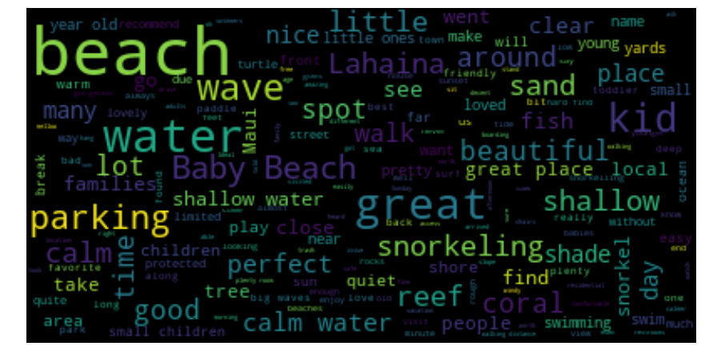

```python
make_wordcloud(reviews2)
```

In contrast to Haleakala National Park, Baby Beach seems like a great place for toddlers.

- proper age indications: little, little ones, kid, young, small (although little or small may have to do with the location rather than age)
- safety: calm, protected, shallow water, shade

Wave may be a red flag, but it is most likely pointing to lack of waves as it is protected. A better natural language processing will filter such results.

### Conclusion

The prelinary analysis shows that Haleakala National Park, which is recommended as "kid-friendly," is not appropriate for toddlers, while Baby Beach, which does not show up as highly ranked "kid-friendly" destination, is great for toddlers. Therefore, the current recommendation system could be improved upon to identify more suitable destinations for toddlers.